# Variable Engineering

```r
library(tidyverse)
library(fastDummies)
```

```r
grades <- read_csv("data/grades.csv")
grades
```

| subject | assignment | tutorial | midterm | take_home | final |
| --- | --- | --- | --- | --- | --- |
| english | 57.14 | 34.09 | 64.38 | 51.48 | 52.50 |
| physics | 95.05 | 105.49 | 67.50 | 99.07 | 68.33 |
| physics | 83.70 | 83.17 | 30.00 | 63.15 | 48.89 |
| maths | 81.22 | 96.06 | 49.38 | 105.93 | 80.56 |
| physics | 91.32 | 93.64 | 95.00 | 107.41 | 73.89 |
| maths | 95.00 | 92.58 | 93.12 | 97.78 | 68.06 |
| physics | 95.05 | 102.99 | 56.25 | 99.07 | 50.00 |
| maths | 72.85 | 86.85 | 60.00 | NA | 56.11 |
| physics | 84.26 | 93.10 | 47.50 | 18.52 | 50.83 |
| maths | 90.10 | 97.55 | 51.25 | 88.89 | 63.61 |

[output cut: 89 more lines]

# Handling missing data

```r
summary(grades)
```

```
   subject            assignment        tutorial         midterm
 Length:99          Min.   : 28.14   Min.   : 34.09   Min.   : 28.12
 Class :character   1st Qu.: 80.88   1st Qu.: 83.35   1st Qu.: 52.81
 Mode  :character   Median : 89.94   Median : 93.10   Median : 69.38
                    Mean   : 85.49   Mean   : 89.73   Mean   : 68.05
                    3rd Qu.: 95.00   3rd Qu.:100.55   3rd Qu.: 82.81
                    Max.   :100.83   Max.   :112.58   Max.   :110.00

   take_home          final
 Min.   : 16.91   Min.   : 28.06
 1st Qu.: 66.02   1st Qu.: 53.12
 Median : 87.96   Median : 66.25
 Mean   : 80.83   Mean   : 68.41
 3rd Qu.: 98.75   3rd Qu.: 84.17
 Max.   :108.89   Max.   :108.89
 NA's   :1        NA's   :3
```

```r
grades <- grades %>%
  mutate(take_home = coalesce(take_home, median(take_home, na.rm = TRUE)),
         final = coalesce(final, median(final, na.rm = TRUE)))

summary(grades)
```

```
   subject            assignment        tutorial         midterm
 Length:99          Min.   : 28.14   Min.   : 34.09   Min.   : 28.12
 Class :character   1st Qu.: 80.88   1st Qu.: 83.35   1st Qu.: 52.81
 Mode  :character   Median : 89.94   Median : 93.10   Median : 69.38
                    Mean   : 85.49   Mean   : 89.73   Mean   : 68.05
                    3rd Qu.: 95.00   3rd Qu.:100.55   3rd Qu.: 82.81
                    Max.   :100.83   Max.   :112.58   Max.   :110.00
   take_home          final
 Min.   : 16.91   Min.   : 28.06
 1st Qu.: 67.96   1st Qu.: 54.16
 Median : 87.96   Median : 66.25
 Mean   : 80.90   Mean   : 68.35
 3rd Qu.: 98.42   3rd Qu.: 83.61
 Max.   :108.89   Max.   :108.89
```

jonny work

```r
grades_imputed <- grades %>%
  group_by(subject) %>%
  mutate(across(where(is.numeric), ~ coalesce(.x, mean(.x, na.rm = TRUE))))

summary(grades_imputed)
```

```
   subject            assignment        tutorial         midterm
 Length:99          Min.   : 28.14   Min.   : 34.09   Min.   : 28.12
 Class :character   1st Qu.: 80.88   1st Qu.: 83.35   1st Qu.: 52.81
 Mode  :character   Median : 89.94   Median : 93.10   Median : 69.38
                    Mean   : 85.49   Mean   : 89.73   Mean   : 68.05
                    3rd Qu.: 95.00   3rd Qu.:100.55   3rd Qu.: 82.81
                    Max.   :100.83   Max.   :112.58   Max.   :110.00
   take_home          final
 Min.   : 16.91   Min.   : 28.06
 1st Qu.: 67.96   1st Qu.: 54.16
 Median : 87.96   Median : 66.25
 Mean   : 80.90   Mean   : 68.35
 3rd Qu.: 98.42   3rd Qu.: 83.61
 Max.   :108.89   Max.   :108.89
```

# Creating dummy variables

```r
grades %>%
  distinct(subject)
```

| subject |
| --- |
| english |
| physics |
| maths |
| french |
| biology |

```r
grades_subject_dummy <- grades %>%
  mutate(subject_engl = ifelse(subject == "english", 1, 0))

head(grades_subject_dummy)
```

| subject | assignment | tutorial | midterm | take_home | final | subject_engl |
| --- | --- | --- | --- | --- | --- | --- |
| english | 57.14 | 34.09 | 64.38 | 51.48 | 52.50 | 1 |
| physics | 95.05 | 105.49 | 67.50 | 99.07 | 68.33 | 0 |
| physics | 83.70 | 83.17 | 30.00 | 63.15 | 48.89 | 0 |
| maths | 81.22 | 96.06 | 49.38 | 105.93 | 80.56 | 0 |
| physics | 91.32 | 93.64 | 95.00 | 107.41 | 73.89 | 0 |
| maths | 95.00 | 92.58 | 93.12 | 97.78 | 68.06 | 0 |

```r
grades_subject_dummy <- grades_subject_dummy %>%
  mutate(subject_phys = ifelse(subject == "physics", 1, 0)) %>%
  mutate(subject_maths = ifelse(subject == "maths", 1, 0)) %>%
  mutate(subject_fren = ifelse(subject == "french", 1, 0)) %>%
  mutate(subject_bio = ifelse(subject == "biology", 1, 0))

head(grades_subject_dummy)
```

| subject | assignment | tutorial | midterm | take_home | final | subject_engl | subject_phys | subject_maths | subject_fren | subject_bio |
| --- | --- | --- | --- | --- | --- | --- | --- | --- | --- | --- |
| english | 57.14 | 34.09 | 64.38 | 51.48 | 52.50 | 1 | 0 | 0 | 0 | 0 |
| physics | 95.05 | 105.49 | 67.50 | 99.07 | 68.33 | 0 | 1 | 0 | 0 | 0 |
| physics | 83.70 | 83.17 | 30.00 | 63.15 | 48.89 | 0 | 1 | 0 | 0 | 0 |
| maths | 81.22 | 96.06 | 49.38 | 105.93 | 80.56 | 0 | 0 | 1 | 0 | 0 |
| physics | 91.32 | 93.64 | 95.00 | 107.41 | 73.89 | 0 | 1 | 0 | 0 | 0 |
| maths | 95.00 | 92.58 | 93.12 | 97.78 | 68.06 | 0 | 0 | 1 | 0 | 0 |

```r
grades_subject_dummy %>%
  select(contains("subject"),
         -subject)
```

| subject_engl | subject_phys | subject_maths | subject_fren | subject_bio |
| --- | --- | --- | --- | --- |
| 1 | 0 | 0 | 0 | 0 |
| 0 | 1 | 0 | 0 | 0 |
| 0 | 1 | 0 | 0 | 0 |
| 0 | 0 | 1 | 0 | 0 |
| 0 | 1 | 0 | 0 | 0 |
| 0 | 0 | 1 | 0 | 0 |
| 0 | 1 | 0 | 0 | 0 |
| 0 | 0 | 1 | 0 | 0 |
| 0 | 1 | 0 | 0 | 0 |
| 0 | 0 | 1 | 0 | 0 |

[output cut: 89 more lines]

```r
grades_subject_dummy <- grades_subject_dummy %>%
  select(-subject)

grades_subject_dummy
```

| assignment | tutorial | midterm | take_home | final | subject_engl | subject_phys | subject_maths | subject_fren | subject_bio |
| --- | --- | --- | --- | --- | --- | --- | --- | --- | --- |
| 57.14 | 34.09 | 64.38 | 51.48 | 52.50 | 1 | 0 | 0 | 0 | 0 |
| 95.05 | 105.49 | 67.50 | 99.07 | 68.33 | 0 | 1 | 0 | 0 | 0 |
| 83.70 | 83.17 | 30.00 | 63.15 | 48.89 | 0 | 1 | 0 | 0 | 0 |
| 81.22 | 96.06 | 49.38 | 105.93 | 80.56 | 0 | 0 | 1 | 0 | 0 |
| 91.32 | 93.64 | 95.00 | 107.41 | 73.89 | 0 | 1 | 0 | 0 | 0 |
| 95.00 | 92.58 | 93.12 | 97.78 | 68.06 | 0 | 0 | 1 | 0 | 0 |
| 95.05 | 102.99 | 56.25 | 99.07 | 50.00 | 0 | 1 | 0 | 0 | 0 |
| 72.85 | 86.85 | 60.00 | 87.96 | 56.11 | 0 | 0 | 1 | 0 | 0 |
| 84.26 | 93.10 | 47.50 | 18.52 | 50.83 | 0 | 1 | 0 | 0 | 0 |
| 90.10 | 97.55 | 51.25 | 88.89 | 63.61 | 0 | 0 | 1 | 0 | 0 |

[output cut: 89 more lines]

## The dummy variable trap

We’ve actually done more work than we really needed to here. We’ve created a dummy variable for every possible value, but in fact that’s one more than we need. Every data point must have a values of “1” for one of the five dummy variables because of how we’ve defined them. Now think about how the dataframe would look if we only had four dummy variables. We would end up with some data points which had a 0 in each column, but because we know that there are only five possible values we can infer this particular data point must have value “1” for the variable which we haven’t represented. In general, if we have n values we only need n-1 dummy variables.

The scenario where we have n dummy variables for n values is known by some as the dummy variable trap. When this occurs we have two or more variables which are multicollinear, ie. one can be predicted from the other(s). Collinearity between variables is undesirable for many machine learning models (including regression), and while we should take care of it at the variable selection stage (a future lesson) it would be better to avoid creating the work for ourselves in the first place!

Note: sometimes creating dummy variables is referred to as one hot encoding. Usually when using the term ‘one hot encoding’ it refers to the creation of n dummy variables, for a model where multicollinearity is not an issue, where as dummy encoding is when we remove one variable to avoid multicollinearity.

```r
grades_subject_dummy2 <- grades %>%
  fastDummies::dummy_cols(select_columns = "subject", remove_first_dummy = TRUE, remove_selected_columns = TRUE)
head(grades_subject_dummy2)
```

| assignment | tutorial | midterm | take_home | final | subject_english | subject_french | subject_maths | subject_physics |
| --- | --- | --- | --- | --- | --- | --- | --- | --- |
| 57.14 | 34.09 | 64.38 | 51.48 | 52.50 | 1 | 0 | 0 | 0 |
| 95.05 | 105.49 | 67.50 | 99.07 | 68.33 | 0 | 0 | 0 | 1 |
| 83.70 | 83.17 | 30.00 | 63.15 | 48.89 | 0 | 0 | 0 | 1 |
| 81.22 | 96.06 | 49.38 | 105.93 | 80.56 | 0 | 0 | 1 | 0 |
| 91.32 | 93.64 | 95.00 | 107.41 | 73.89 | 0 | 0 | 0 | 1 |
| 95.00 | 92.58 | 93.12 | 97.78 | 68.06 | 0 | 0 | 1 | 0 |

```r
assignment_mean <- mean(grades$assignment)
assignment_sd <- sd(grades$assignment)

assignment_mean
```

```
[1] 85.49172
```

```r
assignment_sd
```

```
[1] 12.59769
```

```r
grades_scaled <- grades %>%
  mutate(assignment_scaled = (assignment - assignment_mean) / assignment_sd)

grades_scaled
```

| subject | assignment | tutorial | midterm | take_home | final | assignment_scaled |
| --- | --- | --- | --- | --- | --- | --- |
| english | 57.14 | 34.09 | 64.38 | 51.48 | 52.50 | -2.250548185 |
| physics | 95.05 | 105.49 | 67.50 | 99.07 | 68.33 | 0.758732741 |
| physics | 83.70 | 83.17 | 30.00 | 63.15 | 48.89 | -0.142225806 |
| maths | 81.22 | 96.06 | 49.38 | 105.93 | 80.56 | -0.339087233 |
| physics | 91.32 | 93.64 | 95.00 | 107.41 | 73.89 | 0.462646804 |
| maths | 95.00 | 92.58 | 93.12 | 97.78 | 68.06 | 0.754763760 |
| physics | 95.05 | 102.99 | 56.25 | 99.07 | 50.00 | 0.758732741 |
| maths | 72.85 | 86.85 | 60.00 | 87.96 | 56.11 | -1.003494549 |
| physics | 84.26 | 93.10 | 47.50 | 18.52 | 50.83 | -0.097773226 |
| maths | 90.10 | 97.55 | 51.25 | 88.89 | 63.61 | 0.365803683 |

[output cut: 89 more lines]

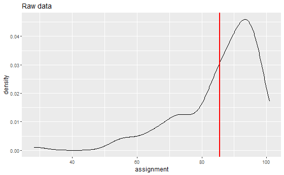

```r
grades %>%
  ggplot(aes(x = assignment)) +
  geom_density() +
  geom_vline(xintercept = mean(grades$assignment), size = 1, colour = "red") +
  labs(title = "Raw data")
```

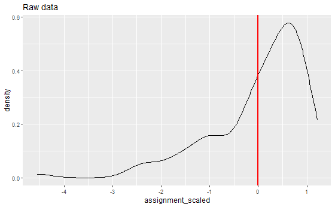

```r
grades_scaled %>%
  ggplot(aes(x = assignment_scaled)) +
  geom_density() +
  geom_vline(xintercept = mean(grades_scaled$assignment_scaled), size = 1, colour = "red") +
  labs(title = "Raw data")
```